# Data Munging / QA / QC / Cleaning

adapted from the [NCEAS dataviz module](https://nceas.github.io/oss-lessons/dataviz-and-interactive-tools/module-1-ggplot2.html) and [R for Data Science](https://r4ds.had.co.nz/data-visualisation.html)

## Learning outcomes

Students should

- Learn what it means to examine and clean their data
- Learn how to reshape and restructure their data with base R

## Lesson

Let’s look at an example dataset (one we’ve made) and go over some ways we might QA/QC this dataset.

It is an arbitrary temperature study with six sites. Within each site, there are 6 plots and we took 10 samples of temperature (degrees C) per plot.

### Step one: Load the data.

Download this csv file with example data in it: fundata.csv

Read in the data (hint - make sure you use the full path to where you saved `fundata.csv`. That could be something like “~/Downloads/fundata.csv”)

```r
fundata <- read.csv("fundata.csv")
head(fundata) # Look at the data
```

```
##   siteplot       date temp_c
## 1      A.1 03-21-2017  31.50
## 2      B.2 04-21-2017  33.63
## 3      C.3 05-21-2017  32.56
## 4      D.4 06-21-2017  31.22
## 5      E.5 07-21-2017  25.44
## 6      F.6 08-21-2017  33.55
```

```r
str(fundata)
```

```
## 'data.frame':    355 obs. of  3 variables:
##  $ siteplot: chr  "A.1" "B.2" "C.3" "D.4" ...
##  $ date    : chr  "03-21-2017" "04-21-2017" "05-21-2017" "06-21-2017" ...
##  $ temp_c  : num  31.5 33.6 32.6 31.2 25.4 ...
```

```r
summary(fundata)
```

```
##    siteplot             date               temp_c
##  Length:355         Length:355         Min.   :-9999.00
##  Class :character   Class :character   1st Qu.:   26.75
##  Mode  :character   Mode  :character   Median :   30.20
##                                        Mean   : -111.25
##                                        3rd Qu.:   33.36
##                                        Max.   :  180.00
##                                        NA's   :1
```

What’s our assessment of this dataset from the above commands?

- The site and plot codes are smushed together in one column.
- The dates look a bit funky. What format is that?
- The range on the temperatures surely can’t be right

#### Split siteplot into two columns

Here’s some example code showing how to generate a dataframe with ugly smashed together variables. and then how to split it out:

```r
library(tidyverse)
lettersdf <- data.frame(letters = paste(LETTERS, rev(LETTERS), sep = "."))
head(lettersdf)
```

```
##   letters
## 1     A.Z
## 2     B.Y
## 3     C.X
## 4     D.W
## 5     E.V
## 6     F.U
```

```r
separate(lettersdf,letters, c("letter_one", "letter_two"), sep = "\\.")
```

```
##    letter_one letter_two
## 1           A          Z
## 2           B          Y
## 3           C          X
## 4           D          W
## 5           E          V
## 6           F          U
## 7           G          T
## 8           H          S
## 9           I          R
## 10          J          Q
## 11          K          P
## 12          L          O
## 13          M          N
## 14          N          M
## 15          O          L
## 16          P          K
## 17          Q          J
## 18          R          I
## 19          S          H
## 20          T          G
## 21          U          F
## 22          V          E
## 23          W          D
## 24          X          C
## 25          Y          B
## 26          Z          A
```

Note: If running `library(tidyverse)` returns an error, you may need to install the tidyverse package. Try `install.packages("tidyverse")`.

**Exercise:** Using your fundata object split the `siteplot` column into two columns called `site` and `plot`:

```r
fundata = separate(fundata, siteplot, c("site", "plot"), sep = "\\.")
```

#### Convert the dates to real R dates

These dates use a format that isn’t wrong, but isn’t ideal for plotting and such. What happens when we try to sort them?

```r
head(sort(fundata$date))
```

```
## [1] "03-21-2016" "03-21-2017" "03-21-2017" "03-21-2017" "03-21-2017" "03-21-2017"
```

Ugh - these are characters, and so it’s not sorting how we might expect. Some of the 2016 dates are after the 2017 dates!

When you have dates in R, it’s usually best to convert them to a `Date` object. The function we’ll use is `as.Date`. Here’s an example of using it on a few dates:

```r
datestrings <- c("2000-08-03", "2017-02-20", "1980-04-27")
class(datestrings) #shows up as being characters
```

```
## [1] "character"
```

```r
mydate <- as.Date(datestrings, format = "%Y-%m-%d")
mydate
```

```
## [1] "2000-08-03" "2017-02-20" "1980-04-27"
```

```r
class(mydate) #now it shows up as being type date!
```

```
## [1] "Date"
```

One more tip - review the course lecture, run through the examples, and recall that you can address columns of a data frame using the `$` syntax.

**Exercise**: Convert the `date` column in `fundata` to from a character vector to a Date vector with `as.Date()`

```r
fundata$date = as.Date(fundata$date, format = "%m-%d-%Y")
```

### Step two: Checking assumptions in the data

#### site and plot columns

Let’s start by looking at the `site` column for potential issues.

The `table` function is a great way to tally the occurrences of each of the unique values in a vector:

```r
table(c("A", "A", "B", "C"))
```

```
##
## A B C
## 2 1 1
```

```r
fish <- c("gag grouper", "striped bass", "red drum", "gag grouper")
table(fish)
```

```
## fish
##  gag grouper     red drum striped bass
##            2            1            1
```

To ahead and apply the `table` function to the `site` column. Based on our experimental design, we expect to see 60 observations from each site. Do we?

#### temp_c column

Get some basic stats about the temp_c column with `summary`:

```r
summary(fundata$temp_c)
```

```
##     Min.  1st Qu.   Median     Mean  3rd Qu.     Max.     NA's
## -9999.00    26.75    30.20  -111.25    33.36   180.00        1
```

Or look directly at the range of values with `range`:

```r
range(fundata$temp_c)
```

```
## [1] NA NA
```

That’s weird - looks like our data contains missing (`NA`) values. Let’s exclude them for now - we’ll deal with them later on.

```r
range(fundata$temp_c,na.rm=TRUE)
```

```
## [1] -9999   180
```

Plotting your data is always a good idea and we can often find new insights or issues this way. For univariate data, a box plot is a great way to look at the distribution of values. Here’s an example of generating 100 values from a normal distribution (using `rnorm`) and plotting them with `boxplot()`:

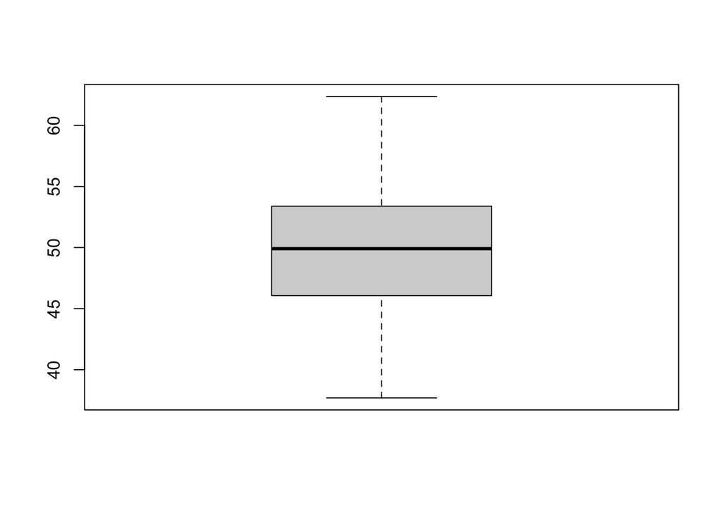

```r
boxplot(rnorm(100, 50, 5))
```

**Exercise** Use the `boxplot()` function to make a boxplot of the temperature values

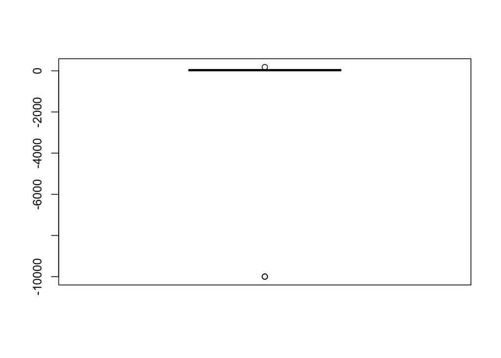

```r
boxplot(fundata$temp_c)
```

Those outlier values can’t be right! Before we move on, let’s fix the -9999 and 180 observations by removing them.

```r
# Remember we can subset the rows in a data.frame like:
fundata[c(1, 2, 3),] # First, second, third rows
```

```
##   site plot       date temp_c
## 1    A    1 2017-03-21  31.50
## 2    B    2 2017-04-21  33.63
## 3    C    3 2017-05-21  32.56
```

```r
#or
head(fundata[which(fundata$site == "A"),]) # Just the rows with site == "A"
```

```
##    site plot       date temp_c
## 1     A    1 2017-03-21  31.50
## 7     A    1 2017-03-21  22.34
## 12    A    1 2016-03-21  31.86
## 18    A    1 2017-03-21  33.91
## 24    A    1 2017-03-21  31.47
## 30    A    1 2017-03-21  37.87
```

**Exercise: Remove the rows with temperatures of -9999 and 180:**

```r
#first, let's find the rows that have wacky temp values and verify that they're the right ones:
which(fundata$temp_c > 150 | fundata$temp_c < -1000)
```

```
## [1] 116 164 258 305 312 320
```

```r
#those are the row numbers, let's look at the actual data
fundata[which(fundata$temp_c > 150 | fundata$temp_c < -1000),]
```

```
##     site plot       date temp_c
## 116    D    4 2017-06-21  -9999
## 164    D    4 2017-06-21  -9999
## 258    C    3 2017-05-21  -9999
## 305    D    4 2017-06-21    180
## 312    E    5 2017-07-21  -9999
## 320    A    1 2017-03-21  -9999
```

```r
#yep, those are the weird ones.  Let's remove them by flipping our selection criteria
fundata = fundata[which(fundata$temp_c < 150 & fundata$temp_c > -1000),]
```

```r
any(is.na(fundata$temp_c))
```

```
## [1] FALSE
```

“NA” is its own type in R.

```r
is.na(2)
```

```
## [1] FALSE
```

```r
is.na(NA)
```

```
## [1] TRUE
```

```r
is.na(c(1, NA, 3))
```

```
## [1] FALSE  TRUE FALSE
```

```r
fish <- c("gag grouper", NA, "red drum", NA)
fish
```

```
## [1] "gag grouper" NA            "red drum"    NA
```

```r
# Filter NAs in a character vector
fish[!is.na(fish)]
```

```
## [1] "gag grouper" "red drum"
```

Your experimental design may dictate the way you handle missing data, but today, we’re just going to remove those rows.

**Exercise** Write an expression using `is.na` to subset fundata, removing rows with missing temperature values and save the result

```r
fundata = fundata[!is.na(fundata$temp_c),]
```

Finally, make a new boxplot using the same commands as above to see if your temperature data is sensible now!

These are some basic tools you can use to validate and clean your data using R. There are lots of approaches to doing this sort of thing, and many packages that make doing it easier. If you are interesting in learning more, there are many great online resources. One we recommend is `R for Data Science`: https://r4ds.had.co.nz/